# Week 4: Joint and Conditional Distributions

PS 812 - Introduction to Statistical Methods in Political Science

Anton Strezhnev

strezhnev@wisc.edu

University of Wisconsin-Madison

September 29, 2026

## Welcome back!

$$\newcommand{\Var}{\text{Var}}
\newcommand{\Cov}{\text{Cov}}
\newcommand{\Corr}{\text{Corr}}
\newcommand{\indep}{\mathrel{\perp\mkern-10mu\perp}}$$

## Week overview

- Last week
  - Random variables
  - Distributions: CDFs, PMFs and PDFs
  - Expectations and variances
- This week
  - **Joint distributions**
  - **Conditional distributions**
  - **Conditional expectations**
  - **Covariances and correlations**

## From one random variable…

[interactive chart not shown]

## Joint distribution functions

- We’ve so far talked about the joint probabilities of **events** $P(A \cap B)$
  - And their **conditional** probabilities: $P(A \mid B)$
- Let’s extend these ideas to talk about **random variables**
- We can define a **joint cumulative distribution function** that takes values of *multiple* variables as inputs
  - For two random variables, $X$ and $Y$

    $$F_{XY}(x, y) = P(X \le x, Y \le y)$$
  - We can generalize to **many** random variables

    $$F_{X_1, \dotsc X_n}(x_1, \dotsc x_n) = P(X_1 \le x_1, \dotsc X_n \le x_n)$$

## A joint CDF

[interactive chart not shown]

## Joint PMFs

- For discrete random variables, we can also talk about the **joint** probability that $X$ takes on a particular value $x$ and $Y$ takes on a particular value $y$
- We define the **joint** probability mass function (PMF) in a similar way as before
  - For two discrete random variables, $X$ and $Y$

    $$p_{XY}(x, y) = P(X = x, Y = y)$$
  - Generalizing to **many** random variables

    $$p_{X_1, \dotsc X_n}(x_1, \dotsc x_n) = P(X_1 = x_1, \dotsc X_n = x_n)$$

## A discrete joint distribution

[interactive chart not shown]

## Joint PDFs

- As before, with continuous random variables $X$ and $Y$, the probability that $X$ or $Y$ take on specific values $x$ and $y$ is zero.
  - We cannot work with a probability mass function $P(X = x, Y = y)$
- Instead, we’ll define a **joint density function** as the derivative of the joint CDF with respect to each of the variables
  - For two continuous random variables, $X$ and $Y$

    $$f_{XY}(x, y) = \frac{\partial^2 F_{XY}(x,y)}{\partial x \partial y}$$
  - Again, generalizing to **many** random variables

    $$f_{X_1, \dotsc X_n}(x_1, \dotsc x_n) = \frac{\partial^n F_{X_1, \dotsc X_n}(x_1, \dotsc x_n)}{\partial x_1 \dotsc \partial x_n}$$

## A continuous joint distribution

[interactive chart not shown]

## Covariance and correlation

- When we have multiple random variables, we may want a **summary** of how the two quantities vary *together*.
  - In the same way we wanted a summary of *central tendency* (**expectation**) or *variability* (**variance**)
- The **covariance** between two random variables $X$ and $Y$ is defined as

  $$\Cov(X, Y) = \mathbb{E}[(X - \mathbb{E}[X])(Y - \mathbb{E}[Y])]$$
- We can factor and apply linearity of expectations to get another way of writing the covariance

  $$\begin{aligned}
  \Cov(X, Y) &= \mathbb{E}[(X - \mathbb{E}[X])(Y - \mathbb{E}[Y])] \\
  &= \mathbb{E}\big[XY - X\,\mathbb{E}[Y] - \mathbb{E}[X]\,Y + \mathbb{E}[X]\,\mathbb{E}[Y]\big] \\
  &= \mathbb{E}[XY] - \mathbb{E}[X]\,\mathbb{E}[Y] - \mathbb{E}[X]\,\mathbb{E}[Y] + \mathbb{E}[X]\,\mathbb{E}[Y] \\
  &= \mathbb{E}[XY] - \mathbb{E}[X]\,\mathbb{E}[Y]
  \end{aligned}$$

## Properties of covariance

- We can pull out constants out of the covariance. Let $a$ and $b$ be constants and $X$ and $Y$ random variables:

  $$\Cov(aX, bY) = ab\Cov(X, Y)$$
- Adding a constant doesn’t change the covariance (just as it doesn’t change the variance)

  $$\Cov(X + a, Y + b) = \Cov(X, Y)$$
- The covariance of any random variable with a constant is $0$

  $$\Cov(X, a) = 0$$
- Covariances have the distributive property

  $$\Cov(X + Z, Y) = \Cov(X, Y) + \Cov(Z, Y)$$

## Covariance and correlation

- Covariance is **scale dependent** - the units in which $X$ and $Y$ are measured matter for the overall magnitude of the covariance.
  - Sometimes we want a **scale free** measure of association as a summary.
- The **correlation** is constructed by normalizing the covariance between $X$ and $Y$ by their respective *standard deviations*

  $$\rho_{X,Y} = \Corr(X, Y) = \frac{\Cov(X, Y)}{\sqrt{\Var(X) \Var(Y)}} = \frac{\Cov(X, Y)}{\sqrt{\Var(X)} \sqrt{\Var(Y)}}$$
- The correlation coefficient lies between $[-1, 1]$
  - These bounds come from an application of the **Cauchy-Schwarz** inequality!

    $$\Cov(X, Y)^2 \le \Var(X) \Var(Y)$$

## Correlation

[interactive chart not shown]

## Properties of variance

- The **covariance** appears when we want to take the variance of a **sum** or **difference** in two random variables.
- The variance of the **sum** of two random variables is:

  $$\Var(X + Y) = \Var(X) + \Var(Y) + 2\Cov(X, Y)$$
- The variance of the **difference** of two random variables is:

  $$\Var(X - Y) = \Var(X) + \Var(Y) - 2\Cov(X, Y)$$
- **Intuitively**:
  - If I add two random variables together, I’m going to get something *noisier* unless $X$ tends to be high when $Y$ is low (and vice-versa)
  - If I subtract two random variables, I’m *also* going to get something *noisier* unless $X$ is high when $Y$ is high (and vice-versa)

## Conditional distributions

- We often want to ask how the distribution of one variable $Y$ **changes** if we were to set $X$ to a particular value
  - As we did before with conditional probabilities, we can define the **conditional distribution** of $Y \mid X$
- For **discrete** random variables, the definition is exactly what we had before: joint over marginal

  $$p_{Y \mid X}(y \mid x) = P(Y = y \mid X = x) = \frac{p_{XY}(x, y)}{p_X(x)}$$
- For **continuous** random variables it’s a bit tricky (since $X = x$ has probability zero), but we use the same approach to define a conditional density

  $$f_{Y \mid X}(y \mid x) = \frac{f_{XY}(x, y)}{f_X(x)}$$
- Think of conditioning on $X = x$ as conditioning on a **tiny window** around $x$: that window appears in the numerator and denominator and cancels, leaving the ratio of densities.

## Factoring joint PMFs/PDFs

- As we did before with the probabilities of intersections of events, we can **factor** joint PMFs and PDFs into the product of conditionals
- For two discrete random variables $X$ and $Y$

  $$p_{XY}(x, y) = p_{Y \mid X}(y \mid x) \cdot p_{X}(x) = p_{X \mid Y}(x \mid y) \cdot p_Y(y)$$
- For two continuous random variables $X$ and $Y$

  $$f_{XY}(x, y) = f_{Y \mid X}(y \mid x) \cdot f_{X}(x) = f_{X \mid Y}(x \mid y) \cdot f_Y(y)$$

## Factoring joint PMFs/PDFs

- This generalizes to **many** random variables:
  - For discrete random variables $X_1, \dotsc, X_N$

    $$\begin{aligned}
    p_{X_1, \dotsc, X_N}(x_1, \dotsc, x_N) &= p_{X_1}(x_1) \cdot p_{X_2 \mid X_1}(x_2 \mid x_1) \cdot p_{X_3 \mid X_1, X_2}(x_3 \mid x_1, x_2) \\
    &\quad \cdots p_{X_N \mid X_1, \dotsc, X_{N-1}}(x_N \mid x_1, \dotsc, x_{N-1}) \\
    &= \prod_{i=1}^{N} p_{X_i \mid X_1, \dotsc, X_{i-1}}(x_i \mid x_1, \dotsc, x_{i-1})
    \end{aligned}$$
- For continuous random variables $X_1, \dotsc, X_N$

  $$\begin{aligned}
  f_{X_1, \dotsc, X_N}(x_1, \dotsc, x_N) &= f_{X_1}(x_1) \cdot f_{X_2 \mid X_1}(x_2 \mid x_1) \cdot f_{X_3 \mid X_1, X_2}(x_3 \mid x_1, x_2) \\
  &\quad \cdots f_{X_N \mid X_1, \dotsc, X_{N-1}}(x_N \mid x_1, \dotsc, x_{N-1}) \\
  &= \prod_{i=1}^{N} f_{X_i \mid X_1, \dotsc, X_{i-1}}(x_i \mid x_1, \dotsc, x_{i-1})
  \end{aligned}$$

## Marginalizing joint distributions

- We can recover a **marginal** distribution from a joint distribution by summing/integrating over whichever variable we want to get rid of
- To get the intuition, we can **factor** the joint density into a conditional and the marginal we care about

  $$f_Y(y) = \int_{-\infty}^{\infty} f_{XY}(x, y) dx = \int_{-\infty}^{\infty} f_{X \mid Y}(x \mid y) f_Y(y) dx$$
- Pull $f_Y(y)$ out of the integral (it doesn’t depend on $x$)

  $$f_Y(y) = f_Y(y) \int_{-\infty}^{\infty} f_{X \mid Y}(x \mid y) dx$$
- And all densities integrate to $1$ (including conditional densities)

  $$f_Y(y) = f_Y(y) \times 1$$

## Visualizing conditional distributions

## Independence

- Two random variables $X$ and $Y$ are **independent** if and only if their joint CDF factors into the product of their **marginal** CDFs
  - Essentially the same definition as before for events!

  $$X \indep Y \iff F_{XY}(x, y) = F_X(x) \, F_Y(y) \quad \text{for all } x, y$$
- This also implies that their joint PMFs/PDFs factor as well

  $$p_{XY}(x, y) = p_X(x) \, p_Y(y) \qquad f_{XY}(x, y) = f_X(x) \, f_Y(y)$$
- Conditioning on one doesn’t change the distribution of the other
  - The marginal and conditional distributions are the same

  $$p_{Y \mid X}(y \mid x) = p_Y(y) \qquad p_{X \mid Y}(x \mid y) = p_{X}(x)$$
  $$f_{Y \mid X}(y \mid x) = f_Y(y) \qquad f_{X \mid Y}(x \mid y) = f_{X}(x)$$

## Independence and Covariance

- Independence implies zero covariance
- First, let’s write $\mathbb{E}[XY]$ as a double sum over the joint PMF using the law of the unconscious statistician.

  $$\mathbb{E}[XY] = \sum_{x} \sum_{y} xy \cdot p_{XY}(x, y)$$
- Independence means the joint distribution factors into the marginals

  $$\mathbb{E}[XY] = \sum_{x} \sum_{y} xy \cdot p_{X}(x) p_{Y}(y)$$
- $x p_X(x)$ factors out of our sum over $y$

  $$\mathbb{E}[XY] = \sum_{x}x \cdot p_{X}(x) \sum_{y} y \cdot p_{Y}(y)$$

## Independence and Covariance

- Plugging in our definitions of expected value

  $$\begin{aligned}
  \mathbb{E}[XY] &= \sum_{x} x \cdot p_{X}(x) \sum_{y} y \cdot p_{Y}(y) \\
  &= \sum_{x} x \cdot p_{X}(x) \, \mathbb{E}[Y] \\
  &= \mathbb{E}[Y] \sum_{x} x \cdot p_{X}(x) \\
  &= \mathbb{E}[X] \, \mathbb{E}[Y]
  \end{aligned}$$
- So the covariance is zero

  $$\Cov(X, Y) = \mathbb{E}[XY] - \mathbb{E}[X] \, \mathbb{E}[Y] = \mathbb{E}[X] \, \mathbb{E}[Y] - \mathbb{E}[X] \, \mathbb{E}[Y] = 0$$

## Conditional expectations

- We often want a **summary** of the conditional distribution of $Y$ given a particular value of $X$.
  - What is a good “prediction” for $Y$ if I know $X$?
- The **regression function** or **conditional expectation function** (CEF) is one such quantity

  $$\mu(x) = \mathbb{E}[Y \mid X = x] =
  \begin{cases}
  \displaystyle \sum_{y} y \cdot p_{Y \mid X}(y \mid x) & \text{discrete } Y \\[1em]
  \displaystyle \int_{-\infty}^{\infty} y \cdot f_{Y \mid X}(y \mid x) \, dy & \text{continuous } Y
  \end{cases}$$
- The CEF is a **function** of $X$
  - I give it a value of $X$, it outputs me what the expected value of $Y$ is for that value of $X$
- Learning about CEFs is at the heart of many social science questions!

## How does Clinton’s 2016 vote share vary by county?

[interactive chart not shown]

## Law of Iterated Expectations

- We can recover the marginal expectation $\mathbb{E}[Y]$ just by applying the expectation operator to $\mathbb{E}[Y \mid X]$
  - But what distribution are we taking that expectation over?
  - The distribution of $X$. Remember $\mathbb{E}[Y \mid X]$ is a function of $X$
- Applying the **law of the unconscious statistician**

  $$\mathbb{E}[Y] = \mathbb{E}\big[\mathbb{E}[Y \mid X]\big] =
  \begin{cases}
  \displaystyle \sum_{x} \mathbb{E}[Y \mid X = x] \cdot p_X(x) & \text{discrete } X \\[1em]
  \displaystyle \int_{-\infty}^{\infty} \mathbb{E}[Y \mid X = x] \cdot f_X(x) \, dx & \text{continuous } X
  \end{cases}$$
- This is known as the **law of total expectation** or **law of iterated expectation**

## Law of Iterated Expectations

- Let’s complete the proof for the discrete case. Substitute in the definition of conditional expectation

  $$\mathbb{E}\big[\mathbb{E}[Y \mid X]\big] = \sum_{x} \sum_{y} y \cdot p_{Y \mid X}(y \mid x) \cdot p_X(x)$$
- That conditional times marginal is just the joint distribution of $X$ and $Y$

  $$\mathbb{E}\big[\mathbb{E}[Y \mid X]\big] = \sum_{x} \sum_{y} y \cdot p_{XY}(x,y)$$
- Pull out the $y$ from the sum over $x$ (remember, we can swap order of summation)
  $$\mathbb{E}\big[\mathbb{E}[Y \mid X]\big] = \sum_{y} y \sum_{x} p_{XY}(x,y)$$

## Law of Iterated Expectations

- The sum over $x$ is just marginalizing out $x$ from the joint distribution of $X$ and $Y$
  $$\begin{aligned}
  \mathbb{E}\big[\mathbb{E}[Y \mid X]\big] &= \sum_{y} y \sum_{x} p_{XY}(x,y) \\
  &= \sum_{y} y \sum_{x} p_{X \mid Y}(x \mid y) \cdot p_Y(y) \\
  &= \sum_{y} y \cdot p_Y(y) \underbrace{\sum_{x} p_{X \mid Y}(x \mid y)}_{= 1} \\
  &= \sum_{y} y \cdot p_Y(y) = \mathbb{E}[Y]
  \end{aligned}$$

## Law of Iterated Expectations

[figure not shown]

## Example: Survey weighting to recalled vote

- We want to predict the 2026 midterm elections.
  - **Problem**: Surveys aren’t representative and we don’t have a perfect way of dealing with **non-response bias**
- A newly popular strategy used by some polling firms is to **weight by recalled vote**
  - Imagine that the voters in 2026 are similar to 2024
  - We have a **known** 2024 benchmark: the observed Trump-Harris vote totals.
  - Calculate average vote choice **conditional** on recalled vote and average using the known 2024 distribution

## Example: Weighting to recalled vote

- **Recent example**: The Economist/YouGov poll (September 25–28, 2026) asks respondents
  - $X$: the respondent’s **recalled** 2024 vote: Trump or Harris
  - $Y_D$: 1 if they intend to vote for the **Democratic** House candidate in 2026, 0 otherwise
  - $Y_R$: 1 if they intend to vote for the **Republican** House candidate in 2026, 0 otherwise
- For each party’s share:

  $$\begin{aligned}
  \mathbb{E}[Y_D] &= \mathbb{E}[Y_D \mid \text{Trump}] \, P(\text{Trump}) + \mathbb{E}[Y_D \mid \text{Harris}] \, P(\text{Harris}) \\
  \mathbb{E}[Y_R] &= \mathbb{E}[Y_R \mid \text{Trump}] \, P(\text{Trump}) + \mathbb{E}[Y_R \mid \text{Harris}] \, P(\text{Harris})
  \end{aligned}$$

## Example: Weighting to recalled vote

- The Economist/YouGov crosstabs report:

  | 2024 vote ($x$) | $\mathbb{E}[Y_D \mid X = x]$ | $\mathbb{E}[Y_R \mid X = x]$ | $P(X = x)$, raw sample | $P(X = x)$, 2024 result |
  | --- | --- | --- | --- | --- |
  | Trump | 0.07 | 0.80 | 0.48 | 0.51 |
  | Harris | 0.90 | 0.01 | 0.52 | 0.49 |

- There are differences in how well each party is holding their voters in 2026
  - 0.90 of Harris voters back the Democratic house candiate, but only 0.80 of Trump voters back the Republican house candidate
  - Trump voters defect to the Democratic candidate (0.07) far more than Harris voters defect to the Republican (0.01)
- But the raw sample **over-represents** Harris voters (0.52 vs. 0.49 in the actual result)

## Example: Weighting to recalled vote

- Averaging over the **2024 result**

  $$\begin{aligned}
  \mathbb{E}[Y_D] &= 0.07 (0.51) + 0.90 (0.49) = 0.477 \\
  \mathbb{E}[Y_R] &= 0.80 (0.51) + 0.01 (0.49) = 0.413
  \end{aligned}$$
- The **margin**, $\mathbb{E}[Y_D] - \mathbb{E}[Y_R]$: the Democratic candidate leads by 6 points
  - The actual poll has it at $45\%$ to $37\%$ because they’re also including 2024 non-voters who are leaning Democratic.
- **Survey weighting** is just the art of figuring out which distribution of $X$ to average over.
  - In Week 13, we’ll talk about how to actually do *estimation*

## The mean minimizes mean squared error

- Why do we focus so much on the **expected value** when thinking about prediction - why is it our “best guess”?
  - It turns out we can formalize the notion of “best guess” with respect to a particular error: the **mean squared error** (MSE)
- Let $c$ be our single guess. The mean squared error between $Y$ and $c$ is defined as $\mathbb{E}[(Y - c)^2]$
  - We want to find the value of $c$ that **minimizes** this quantity.

## The mean minimizes mean squared error

- Add and subtract $\mathbb{E}[Y]$ and expand the square

  $$\begin{aligned}
  \mathbb{E}[(Y - c)^2] &= \mathbb{E}\big[\big((Y - \mathbb{E}[Y]) + (\mathbb{E}[Y] - c)\big)^2\big] \\
  &= \mathbb{E}[(Y - \mathbb{E}[Y])^2] + 2(\mathbb{E}[Y] - c)\,\mathbb{E}[Y - \mathbb{E}[Y]] + (\mathbb{E}[Y] - c)^2 \\
  &= \Var(Y) + (\mathbb{E}[Y] - c)^2
  \end{aligned}$$
- The middle term drops out because $\mathbb{E}[Y - \mathbb{E}[Y]] = 0$
- $\Var(Y)$ doesn’t depend on $c$, and $(\mathbb{E}[Y] - c)^2 \ge 0$, so the MSE is smallest at $c = \mathbb{E}[Y]$
  - The best constant prediction with respect to MSE is the **mean**, and the smallest achievable MSE is the **variance**

## The CEF minimizes the MSE

- Now, instead of a single constant $c$, we can plug in a **function** of $X$, $g(X)$
  - We can show that the function $g(X)$ that does the **best** job is the CEF.
- The MSE between $Y$ and our function is $\mathbb{E}[(Y - g(X))^2]$ and we’re searching over the space of all possible functions $g()$
- We’ll use a similar trick from before: add and subtract the CEF $\mu(X) = \mathbb{E}[Y \mid X]$ and expand the square:

  $$\begin{aligned}
  \mathbb{E}[(Y - g(X))^2] &= \mathbb{E}[(Y - \mu(X))^2] + 2\,\mathbb{E}[(Y - \mu(X))(\mu(X) - g(X))] \\
  &\quad + \mathbb{E}[(\mu(X) - g(X))^2]
  \end{aligned}$$

## The CEF minimizes the MSE

- The middle term is zero: by the **law of total expectation**, condition on $X = x$ first. Given $X = x$, $\mu(x) - g(x)$ is just a constant

  $$\mathbb{E}[(Y - \mu(x))(\mu(x) - g(x)) \mid X = x] = (\mu(x) - g(x))\underbrace{\big(\mathbb{E}[Y \mid X = x] - \mu(x)\big)}_{=0} = 0$$
- So for any $g$

  $$\mathbb{E}[(Y - g(X))^2] = \mathbb{E}[(Y - \mu(X))^2] + \underbrace{\mathbb{E}[(\mu(X) - g(X))^2]}_{\ge 0} \ge \mathbb{E}[(Y - \mu(X))^2]$$
- The CEF is the **best predictor** of $Y$ given $X$ in MSE.

## Estimating the CEF: Clinton’s 2016 vote share

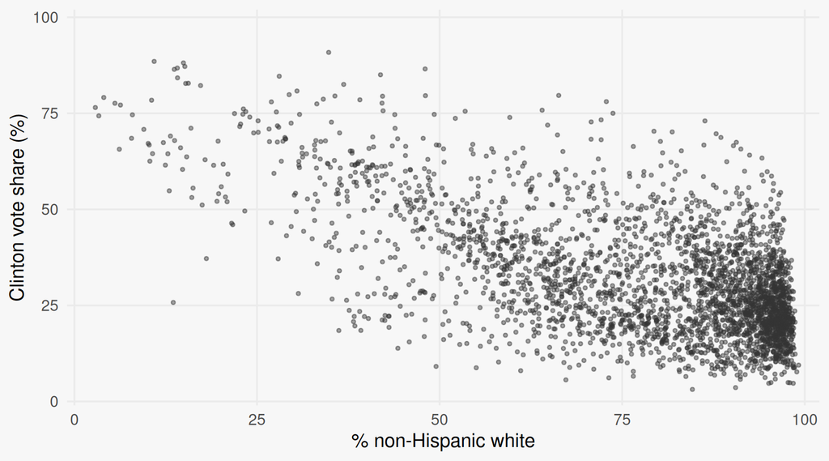

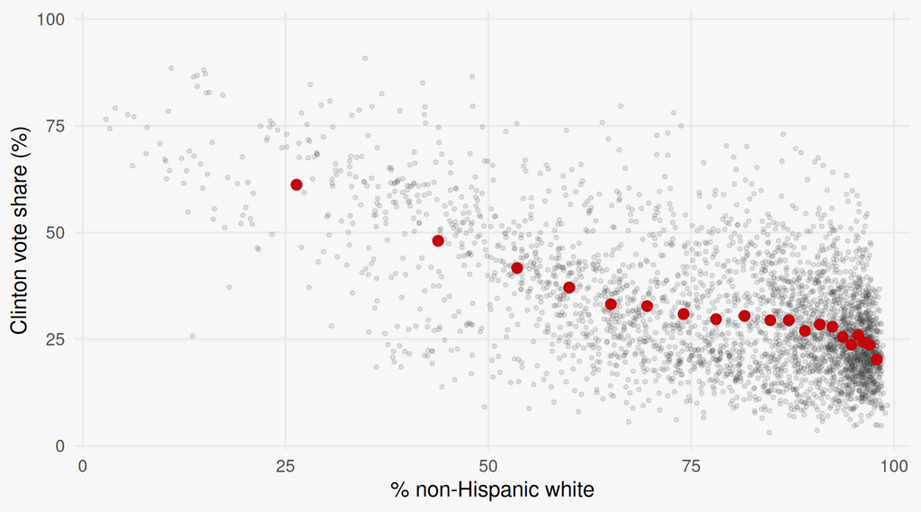

## Estimating the CEF: Clinton’s 2016 vote share

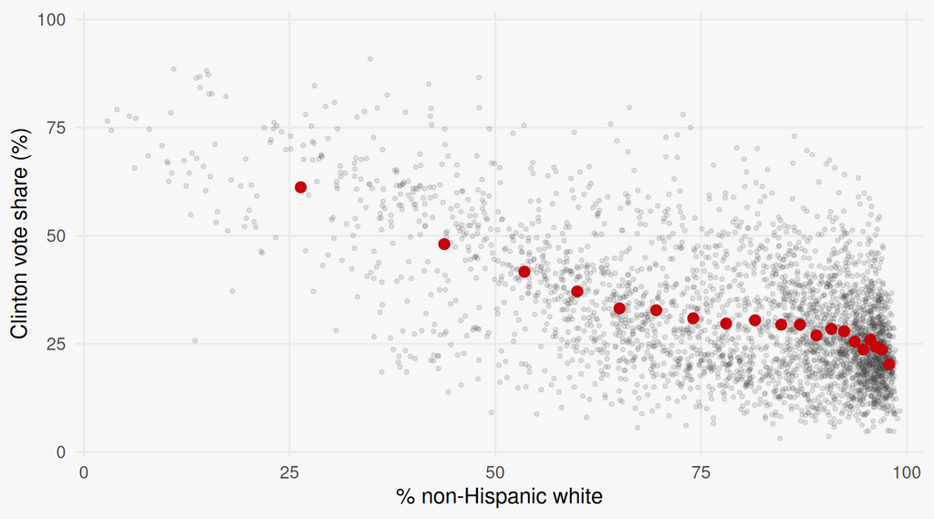

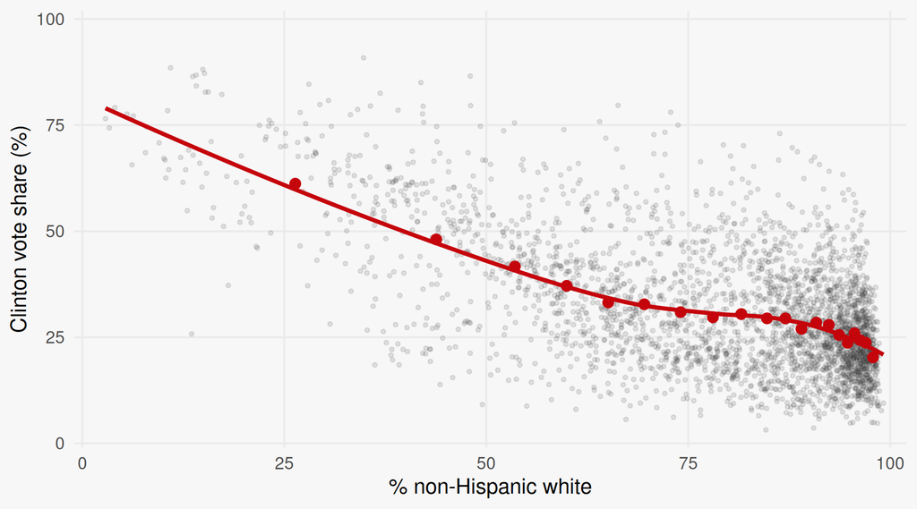

## How fast does the CEF change?

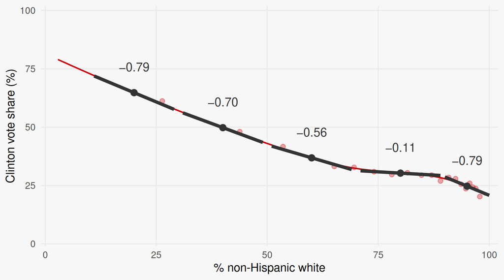

## The best linear predictor

- The CEF can take **any** shape, which makes it hard to summarize when $X$ is continuous or high-dimensional.
  - Often we have hypotheses about a **rate of change** in an outcome as an independent variable increases or decreases
  - We want to estimate a **single number** to summarize an (average) rate of change.
- What if we **restrict** $g(X)$ to be a line, $g(X) = a + bX$?
- The **best linear predictor** (BLP) is the line with the smallest MSE

  $$(\alpha, \beta) = \arg\min_{a,\, b} \ \mathbb{E}\big[(Y - a - bX)^2\big]$$
- We are searching over a **smaller** space of options

  $$\mathbb{E}\big[(Y - \mu(X))^2\big] \le \mathbb{E}\big[(Y - \alpha - \beta X)^2\big]$$

## The best linear predictor

- Let’s solve this optimization problem by taking the derivatives with respect to $a$ and $b$ and solving for $0$
- Derivative passes inside the expectation. Then applying the chain rule…

  $$\begin{aligned}
  \frac{\partial}{\partial a} \mathbb{E}\big[(Y - a - bX)^2\big] &= \mathbb{E}\big[2(Y - a - bX) \cdot (-1)\big] = -2\,\mathbb{E}[Y - a - bX] \\
  \frac{\partial}{\partial b} \mathbb{E}\big[(Y - a - bX)^2\big] &= \mathbb{E}\big[2(Y - a - bX) \cdot (-X)\big] = -2\,\mathbb{E}\big[X(Y - a - bX)\big]
  \end{aligned}$$
- Set both to $0$ at $(a, b) = (\alpha, \beta)$ and divide both sides by $-2$

  $$\mathbb{E}[Y - \alpha - \beta X] = 0 \qquad \mathbb{E}\big[X(Y - \alpha - \beta X)\big] = 0$$

## The best linear predictor

- This gives the **first-order conditions** for the optimization problem

  $$\mathbb{E}[Y - \alpha - \beta X] = 0 \qquad \mathbb{E}\big[X(Y - \alpha - \beta X)\big] = 0$$
- The first gives the intercept: $\alpha = \mathbb{E}[Y] - \beta\,\mathbb{E}[X]$
- Plug it into the second

  $$\begin{aligned}
  0 &= \mathbb{E}[XY] - \alpha\,\mathbb{E}[X] - \beta\,\mathbb{E}[X^2] \\
  &= \mathbb{E}[XY] - \mathbb{E}[X]\,\mathbb{E}[Y] - \beta\big(\mathbb{E}[X^2] - \mathbb{E}[X]^2\big) \\
  &= \Cov(X, Y) - \beta \Var(X)
  \end{aligned}$$
- So the BLP is

  $$\beta = \frac{\Cov(X, Y)}{\Var(X)} \qquad \alpha = \mathbb{E}[Y] - \beta\,\mathbb{E}[X]$$

## The best linear predictor

- Recall that for **any** function $g$

  $$\mathbb{E}[(Y - g(X))^2] = \mathbb{E}[(Y - \mu(X))^2] + \mathbb{E}[(\mu(X) - g(X))^2]$$
- The first term doesn’t depend on $g$. So among lines, minimizing the MSE for $Y$ is the same as minimizing the distance to the CEF

  $$(\alpha, \beta) = \arg\min_{a,\, b} \ \mathbb{E}\big[(\mu(X) - a - bX)^2\big]$$
  - The BLP is the best **linear approximation to the CEF**
  - If the CEF is linear, the BLP **is** the CEF
- Like the CEF, the BLP is a feature of the joint distribution: an **estimand**
- For our Clinton vote share example: $\beta \approx -0.46$.
  - Each additional increase in county % non-Hispanic white is associated with about half a point reduction in Clinton vote share

## Estimating the BLP: Clinton’s 2016 vote share

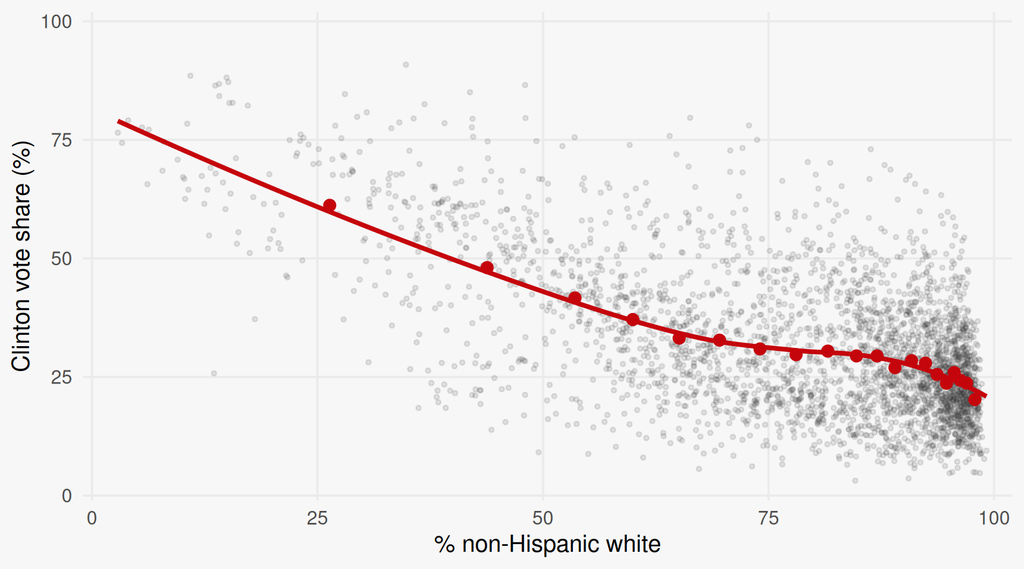

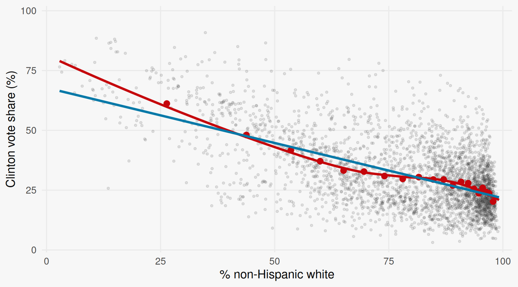

## Bonus: The law of total variance

- We can also decompose the variance of $Y$ by conditioning on $X$

  $$\Var(Y) = \underbrace{\mathbb{E}\big[\Var(Y \mid X)\big]}_{\text{within}} + \underbrace{\Var\big(\mathbb{E}[Y \mid X]\big)}_{\text{between}}$$
- **Within**: the average spread of $Y$ around the CEF *inside* each slice of $X$
- **Between**: how much the CEF itself moves as $X$ changes. The part of the variation in $Y$ “explained” by $X$
- In the recalled vote example ($Y_D$ is binary, so $\Var(Y_D \mid X = x) = \mu(x)(1 - \mu(x))$)
  - Within: 0.077, between: 0.172, total: $\Var(Y_D) =$ 0.249
  - Recalled 2024 vote accounts for about 69% of the variance in 2026 House vote preference

## Bonus: The law of total variance

- Start from $\Var(Y \mid X) = \mathbb{E}[Y^2 \mid X] - \mathbb{E}[Y \mid X]^2$ and take expectations of each piece, using the **law of iterated expectations**

  $$\begin{aligned}
  \mathbb{E}\big[\Var(Y \mid X)\big] &= \mathbb{E}\big[\mathbb{E}[Y^2 \mid X]\big] - \mathbb{E}\big[\mathbb{E}[Y \mid X]^2\big] = \mathbb{E}[Y^2] - \mathbb{E}\big[\mathbb{E}[Y \mid X]^2\big] \\
  \Var\big(\mathbb{E}[Y \mid X]\big) &= \mathbb{E}\big[\mathbb{E}[Y \mid X]^2\big] - \mathbb{E}\big[\mathbb{E}[Y \mid X]\big]^2 = \mathbb{E}\big[\mathbb{E}[Y \mid X]^2\big] - \mathbb{E}[Y]^2
  \end{aligned}$$
- Add the two lines: the $\mathbb{E}\big[\mathbb{E}[Y \mid X]^2\big]$ terms cancel

  $$\mathbb{E}\big[\Var(Y \mid X)\big] + \Var\big(\mathbb{E}[Y \mid X]\big) = \mathbb{E}[Y^2] - \mathbb{E}[Y]^2 = \Var(Y)$$
- Since both pieces are non-negative, conditioning never *adds* variance: $\Var\big(\mathbb{E}[Y \mid X]\big) \le \Var(Y)$

## Next week

- What is your **estimand**?
  - How should we connect theory to empirical questions?
  - Thinking of estimands as features of distributions.
  - Preview of *descriptive* versus *causal* estimands
- **Midterm** exam
  - Probability questions in the *context* of actual research settings.
  - Focus on properties of conditional probability, properties of expectations.

## References

Anscombe, F. J. 1973. “Graphs in Statistical Analysis.” *The American Statistician* 27 (1): 17–21. https://doi.org/10.1080/00031305.1973.10478966.

Matejka, Justin, and George Fitzmaurice. 2017. “Same Stats, Different Graphs: Generating Datasets with Varied Appearance and Identical Statistics Through Simulated Annealing.” *Proceedings of the 2017 CHI Conference on Human Factors in Computing Systems*, 1290–94. https://doi.org/10.1145/3025453.3025912.